# p8105_hw6_jn2761

jiaying Ning

11/30/2020

load packages

## Problem 1

### Import data

```r
birthweight_df = read_csv("./data/birthweight.csv") %>%
  na.omit()
```

From description of variable, we know that variable`babysex`, `frace`,`malform`,`mrace` should be factor

```r
birthweight_df=
birthweight_df %>%
   mutate(babysex = ifelse(babysex == 1, "male","female"),
     malform = ifelse(malform == 0, "absent","present"),
          frace = recode(frace, `1` = "White", `2`="Black", `3` = "Asian", `4` = "Puerto Rican", `8` = "Other", `9` = "Unknown"),
          mrace = recode(mrace, `1` = "White", `2`="Black", `3` = "Asian", `4` = "Puerto Rican", `8` = "Other"))
```

### Propose a regression model for birthweight

In order to find the variable of interest, I did research on the potential risk factor that influence newborn’s birthwright, and here is what I found:

- *The present study revealed that* *maternal illiteracy, exposure to passive smoking, late child bearing, shorter inter-pregnancy interval, previous LBW baby, maternal weight, weight gain during pregnancy, PIH, high risk pregnancy and late antenatal registration* *were the risk factors significantly associated with the birth weight of a newborn(Metgud,2012)*
- [Click Here to see the original paper](https://www.ncbi.nlm.nih.gov/pmc/articles/PMC3390317/#)

For the current homework, I will choose variable`gaweeks`(as measurement for inter-pregnancy interval) and `momage`(as measurement for late child bearing)as my predictor, and `bwt` as my outcome.

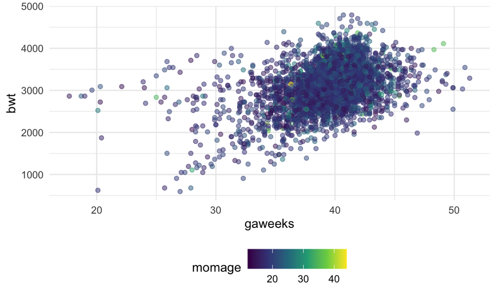

```r
birthweight_df %>%
  ggplot(aes(x=gaweeks,y=bwt,color=momage))+
  geom_point(alpha=0.5)
```

Fit in a linear model:

```r
Lin_mod = lm(bwt ~ momage + gaweeks, data = birthweight_df)
broom::tidy(Lin_mod)
```

```
## # A tibble: 3 x 5
##   term        estimate std.error statistic   p.value
##   <chr>          <dbl>     <dbl>     <dbl>     <dbl>
## 1 (Intercept)    300.      92.4       3.25 1.17e-  3
## 2 momage          11.9      1.83      6.50 9.23e- 11
## 3 gaweeks         65.3      2.25     29.0  2.83e-169
```

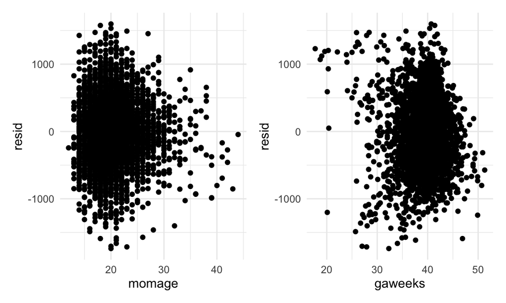

```r
library(patchwork)

momage_res=
modelr::add_residuals(birthweight_df, Lin_mod) %>%
  ggplot(aes(x=momage,y=resid))+
   geom_point()

gaweeks_res=
modelr::add_residuals(birthweight_df, Lin_mod) %>%
  ggplot(aes(x=gaweeks,y=resid))+
   geom_point()

momage_res+gaweeks_res
```

### Comparing with two other model

#### 1. length at birth and gestational age as predictors (main effects only)

```r
mod1 = lm(bwt ~ blength + gaweeks, data = birthweight_df)
```

#### 2. head circumference, length, sex, and all interactions (including the three-way interaction)

```r
mod2 = lm(bwt ~ bhead + blength + babysex + bhead*blength + bhead*babysex + blength*babysex + bhead*blength*babysex, data = birthweight_df)
```

#### Compare

```r
cv_df=
  crossv_mc(birthweight_df,100) %>%
  mutate(
    train = map(train, as_tibble),
    test = map(test, as_tibble)) %>%
  mutate(
    mod0  = map(train, ~lm(bwt ~ momage + gaweeks, data = .x)),
    mod1  = map(train, ~lm(bwt ~ blength + gaweeks, data = .x)),
    mod2  = map(train, ~lm(bwt ~ bhead + blength + babysex + bhead*blength + bhead*babysex + blength*babysex + bhead*blength*babysex, data = .x))) %>%
  mutate(
    rmse_mod0 = map2_dbl(mod0, test, ~rmse(model = .x, data = .y)),
    rmse_mod1 = map2_dbl(mod1, test, ~rmse(model = .x, data = .y)),
    rmse_mod2 = map2_dbl(mod2, test, ~rmse(model = .x, data = .y)))
```

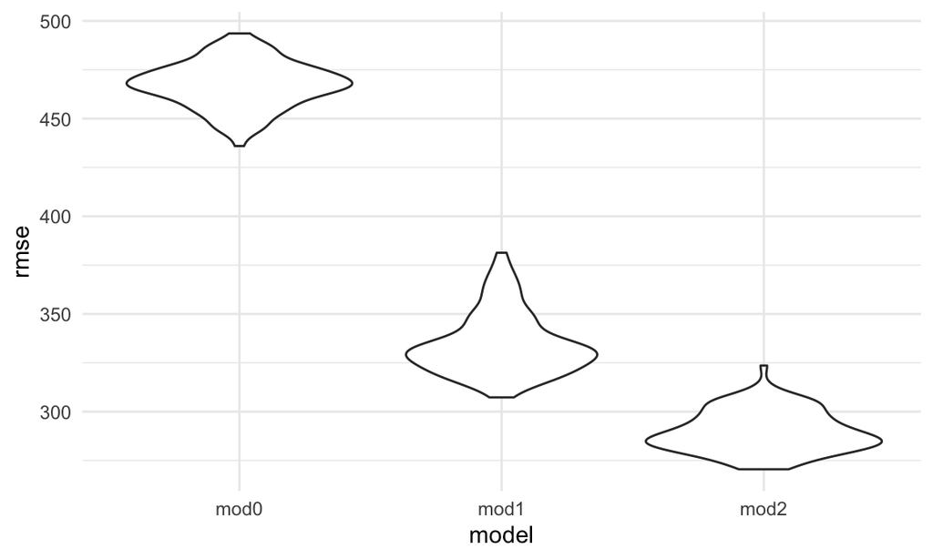

```r
cv_df %>%
  select(starts_with("rmse")) %>%
  pivot_longer(
    everything(),
    names_to = "model",
    values_to = "rmse",
    names_prefix = "rmse_") %>%
  mutate(model = fct_inorder(model)) %>%
  ggplot(aes(x = model, y = rmse)) + geom_violin()
```

```r
cv_df %>%
  select(starts_with("rmse")) %>%
  pivot_longer(
    everything(),
    names_to = "model",
    values_to = "rmse",
    names_prefix = "rmse_") %>%
  group_by(model) %>%
  summarize(avg_rmse = mean(rmse))
```

```
## # A tibble: 3 x 2
##   model avg_rmse
##   <chr>    <dbl>
## 1 mod0      467.
## 2 mod1      335.
## 3 mod2      290.
```

In here we see that model 2 (head circumference, length, sex, and all interactions) have the smallest root mean squared errors, thus provide the best model for predicting birthweight

## Problem 3

### Import data

```r
weather_df =
  rnoaa::meteo_pull_monitors(
    c("USW00094728"),
    var = c("PRCP", "TMIN", "TMAX"),
    date_min = "2017-01-01",
    date_max = "2017-12-31") %>%
  mutate(
    name = recode(id, USW00094728 = "CentralPark_NY"),
    tmin = tmin / 10,
    tmax = tmax / 10) %>%
  select(name, id, everything())
```

```
## using cached file: /Users/jiayingning/Library/Caches/R/noaa_ghcnd/USW00094728.dly
```

```
## date created (size, mb): 2020-10-08 12:25:57 (7.525)
```

```
## file min/max dates: 1869-01-01 / 2020-10-31
```

### Bootstrapping

```r
weather_bootstrap=
weather_df %>%
  modelr::bootstrap(n = 5000) %>%
  mutate(
    models = map(strap, ~ lm(tmax ~ tmin, data = .x)))
```

#### Plot distribution of estimate

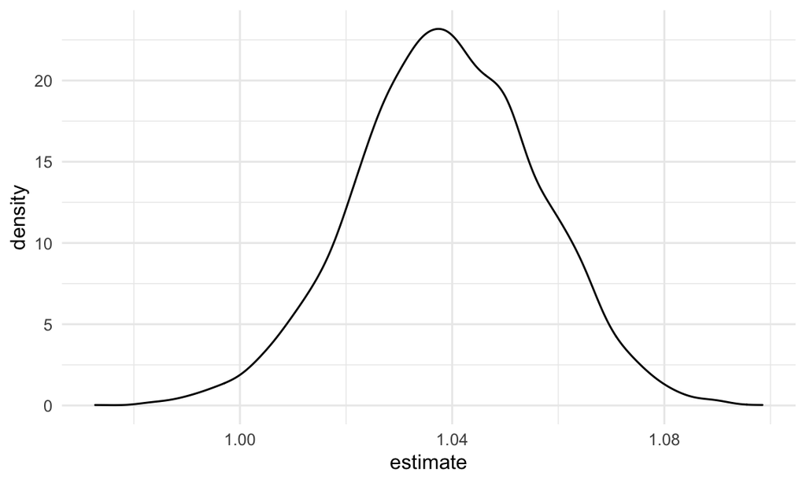

```r
weather_bootstrap %>%
  mutate(results = map(models, broom::tidy)) %>%
  select(results) %>%
  unnest(results) %>%
    filter(term == "tmin") %>%
  ggplot(aes(x = estimate)) + geom_density()
```

This distribution of regression coefficient is relatively normal, which means that bootstrap has succefully resample the dataset with replacement and establish normality and satisified distributional assumption.

#### 95% confidence interval for r̂ 2

```r
weather_bootstrap%>%
  mutate(
    results = map(models, broom::glance)) %>%
  select(results) %>%
  unnest(results) %>%
  summarise(
    ci_lower=quantile(r.squared,0.025),
    ci_upper=quantile(r.squared,0.975)
  )
```

```
## # A tibble: 1 x 2
##   ci_lower ci_upper
##      <dbl>    <dbl>
## 1    0.894    0.927
```

#### 95% confidence interval for log(β̂ 0∗β̂ 1)

```r
weather_bootstrap%>%
   mutate(
    results = map(models, broom::tidy))%>%
  select(results,.id) %>%
  unnest(results)  %>%
  select(term,estimate,.id)%>%
  pivot_wider(
  names_from = "term",
  values_from = "estimate")%>%
  unnest()%>%
  mutate( log = log(`(Intercept)`*tmin)) %>%
  summarise(
    ci_lower=quantile(log,0.025),
    ci_upper=quantile(log,0.975)
  )
```

```
## # A tibble: 1 x 2
##   ci_lower ci_upper
##      <dbl>    <dbl>
## 1     1.96     2.06
```